# R Notebook

```r
library(tidyverse)
# load thea data
project <- read_csv("data/project_management.csv")
project <- project %>%
  select(-...1)
```

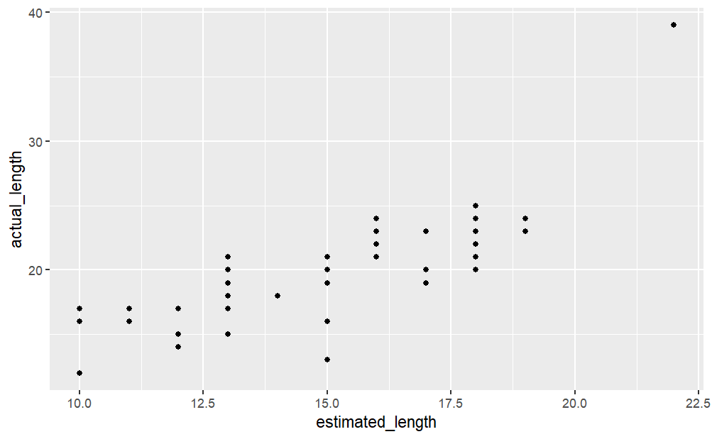

```r
# Plot the data, taking estimated_length as the independent variable and actual_length as the dependent variable.


project %>%
  ggplot(aes(estimated_length, actual_length))+
  geom_point()
```

```r
# Calculate the correlation coefficient of estimated_length and actual_length and interpret the value you obtain.

project %>% summarise(correlation = cor(estimated_length, y = actual_length))
```

| correlation |
| --- |
| 0.8046597 |

The correlation between estimated_length and actual_length of the project shows a strong correlation.

```r
# Perform a simple linear regression using actual_length as the dependent variable, and estimated_length as the independent variable. Save the model object to a variable.

model <- lm(formula = actual_length ~ estimated_length, data = project)
```

```r
library(modelr)
sample <- project %>%
  add_predictions(model) %>%
  add_residuals(model)
```

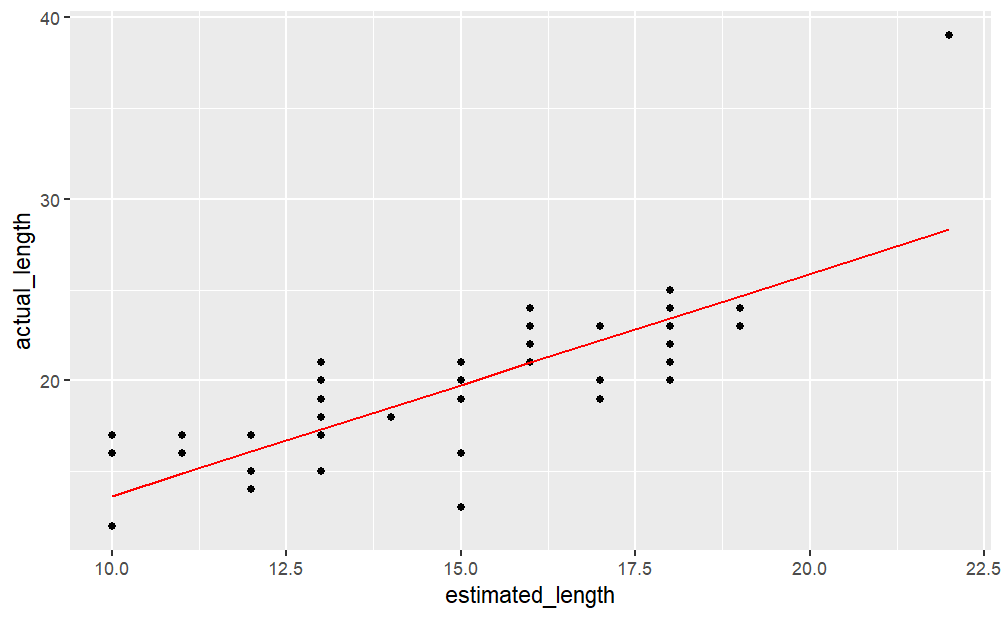

```r
sample %>%
  ggplot(aes(x = estimated_length))+
  geom_point( aes(y = actual_length))+
  geom_line(aes(y = pred), col = "red")
```

Interpret the regression coefficient of estimated_length (i.e. slope, gradient) you obtain from the model. How do you interpret the r2 value reported by the model? Positive correlation between estimated and actual length of a project.

a 1 day increase in estimated_length is associated with a 1.2235 day increase in actual_length, i.e. the company is underestimating job lengths.

The r2 value tells us that approximately 65% of the variation in actual_length can be predicted from the variation in estimated_length.

```r
library(broom)
glance(model)
```

| r.squared | adj.r.squared | sigma | statistic | p.value | df | logLik | AIC | BIC | deviance | df.residual | nobs |
| --- | --- | --- | --- | --- | --- | --- | --- | --- | --- | --- | --- |
| 0.6474772 | 0.640133 | 2.606163 | 88.16142 | 1.911284e-12 | 1 | -117.8203 | 241.6407 | 247.3767 | 326.0201 | 48 | 50 |

```r
tidy(model)
```

| term | estimate | std.error | statistic | p.value |
| --- | --- | --- | --- | --- |
| (Intercept) | 1.416379 | 2.0069491 | 0.7057375 | 4.837627e-01 |
| estimated_length | 1.223489 | 0.1303049 | 9.3894314 | 1.911284e-12 |

```r
library(ggfortify)
autoplot(model)
```

[output not shown]

checking the independence of variables (residuals vs fitted) - looks like they’re independent. Normal Q-Q tests the normality of residuals - it looks like the residuals are normally distributed. It looks like the relationship is statistically significant.

Assumptons of linear regression: 1. The relationship is linear(residuals vs fitted) 2. (Error) residuals should be normally distributed (Q-Q plot) 3. Homoscedastic errors: - constant variance

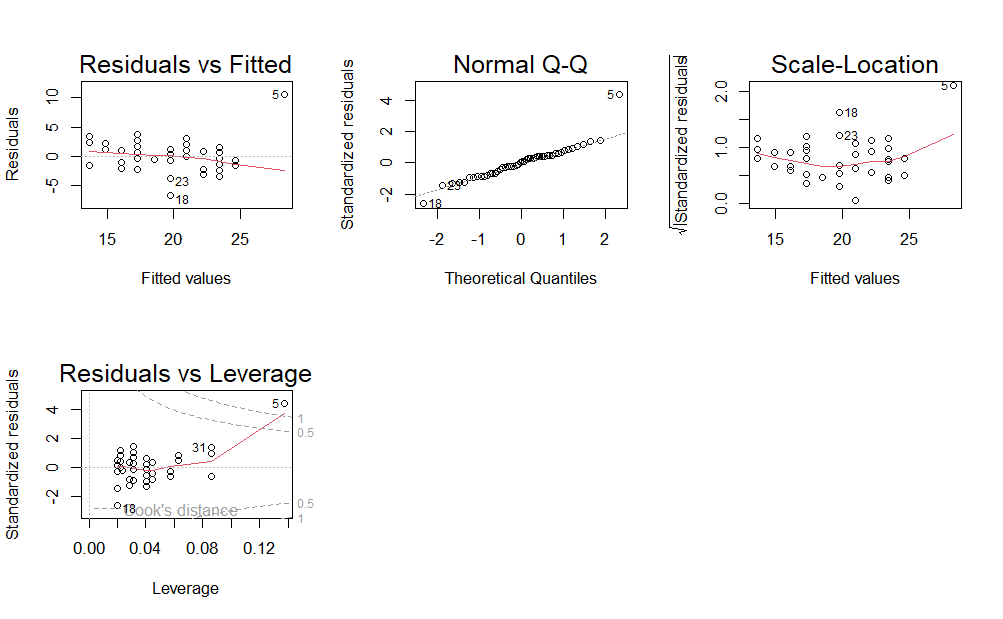

```r
 par(mfrow =  c(2,3))
plot(model)

hist(model$residuals)
```

[output not shown]